# Лабораторная работа №4

Продвинутое использование Git

Губайдуллина Софья Романовна

Российский университет дружбы народов, Москва, Россия

08 марта 2024

# Вводная часть

## Актуальность

Актуальность использования системы контроля версий Git обьясняется его распространенностью среди студентов и будущих программистов. С помощью Git удобно хранить информацию и работать с проектами удаленно и совместно.

## Объект и предмет исследования

Обьект исследования: Система контроля версий GitHub. Предмет исследования: Настройка продвинутой версии Git.

## Цели

Получение навыков правильной работы с репозиториями git.

## Задачи

1. Установка Gitflow;
2. Установка Node.js;
3. Настройка Node.js;
4. Общепринятые коммиты;
5. Практический сценарий использования git;
6. Работа с репозиторием git.

# Выполнение работы

## Установка Gitflow

1. Для того, чтобы установить git flow, устанавливаю коллекцию репозиториев Copr (рис. [-@fig:001]).

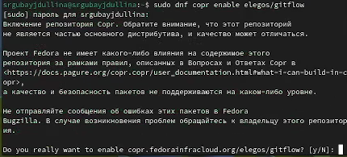

Установка репозиториев Copr

## Установка Gitflow

Далее устанавливаю сам git flow через консоль (рис. [-@fig:002])

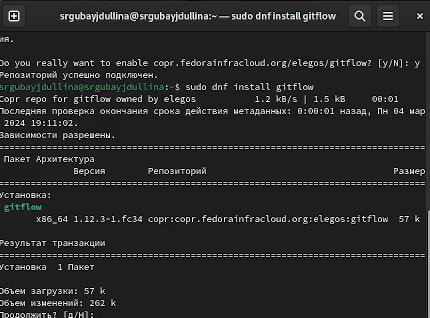

Установка git flow

## Установка Node.js

2. Устанавливаю Node.js - базу для программного обеспечения семантического версионирования и коммитов (рис. [-@fig:003])

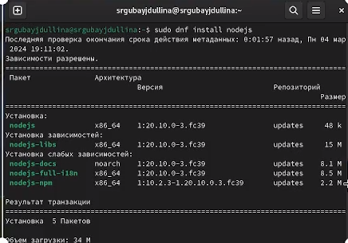

Установка Node.js

## Настройка Node.js

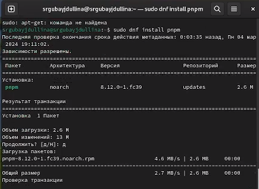

Настройка Node.js

## Настройка Node.js

Запускаю pnpm setup, перелогинюсь и захожу (рис. [-@fig:005]).

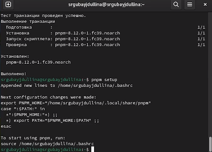

Pnpm setup

## Общепринятые коммиты

4. Устанавливаю программу commitizen для помощи в форматировании коммитов.(рис. [-@fig:006]).

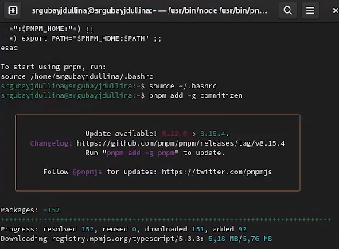

Установка commitizen

## Общепринятые коммиты

Устанавливаю программу standard-changelog, которая используется для помощи в создании логов (рис. [-@fig:007]).

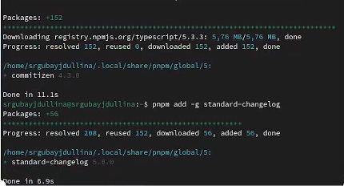

Установка standard-changelog

## Практический сценарий использования git

5. Созданию новый репозиторий git и назову его git-extended (рис. [-@fig:008]).

[figure not shown]

Создание нового репозитория

## Практический сценарий использования git

При помощи git commit делаю первый коммит и выкладываю на гитхаб (рис. [-@fig:009]).

[figure not shown]

Первый коммит

## Практический сценарий использования git

Требуется конфигурация для пакетов Node.js (рис. [-@fig:010]).

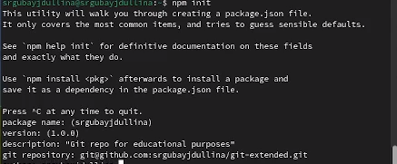

nmp init

## Практический сценарий использования git

Добавляю новые файлы, выполняю коммиты и отправляю файлы на сервер (рис. [-@fig:012]).

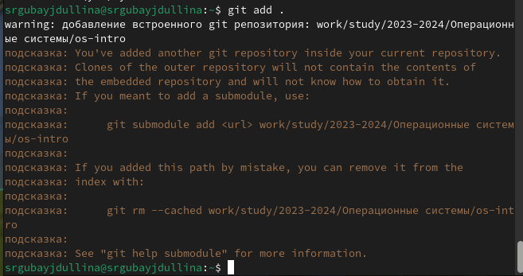

Git add

## Практический сценарий использования git

Выполненный коммит (рис. [-@fig:013]):

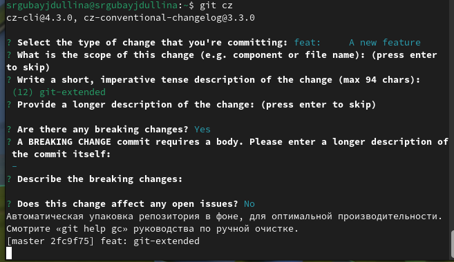

Git cz

## Практический сценарий использования git

Git push (рис. [-@fig:014]):

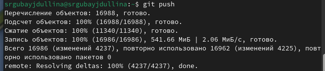

Отправка на сервер

## Практический сценарий использования git

Произвожу инициализацию git flow (рис. [-@fig:015]).

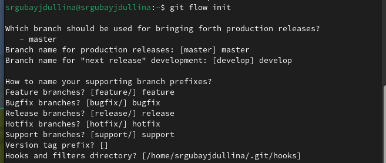

Git flow init

## Практический сценарий использования git

Загружаю весь репозиторий в хранилище (рис. [-@fig:016]).

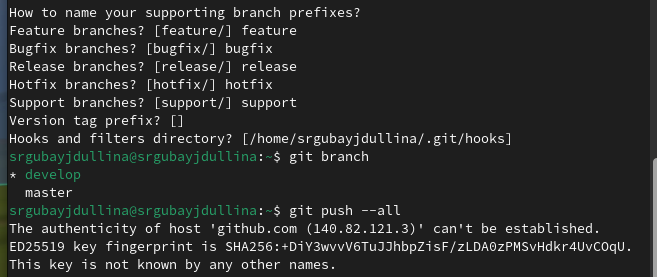

Git branch и загрузка всего репозитория

## Практический сценарий использования git

Git push –all (рис. [-@fig:017]):

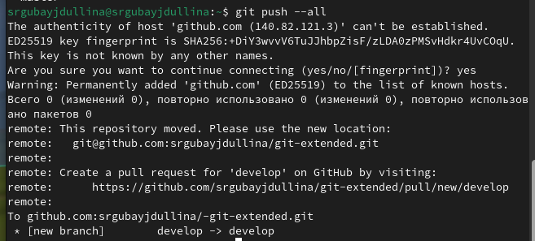

Загрузка всего репозитория

## Практический сценарий использования git

Устанавливаю внешнюю ветку как вышестоящую для этой ветки (рис. [-@fig:018]).

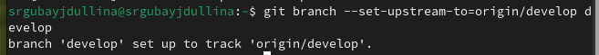

Установка внешней ветки

## Практический сценарий использования git

Создаю релиз с версией 1.0.0 (рис. [-@fig:019]).

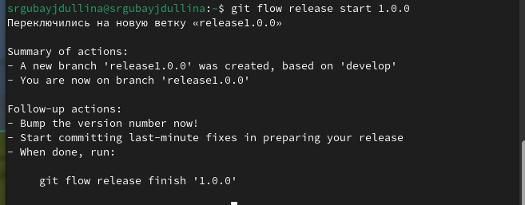

Версия 1.0.0

## Практический сценарий использования git

Создаю журнал изменений git standard, а так же добавляю его в индекс (рис. [-@fig:020]).

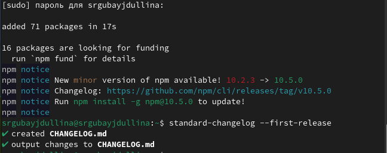

Журнал изменений

## Практический сценарий использования git

Commit (рис. [-@fig:021]):

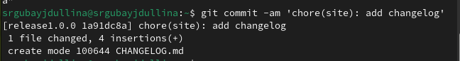

Commit changes

## Практический сценарий использования git

Залив релизной ветки в основную ветку и отправкаи данных на GitHub (рис. [-@fig:022]).

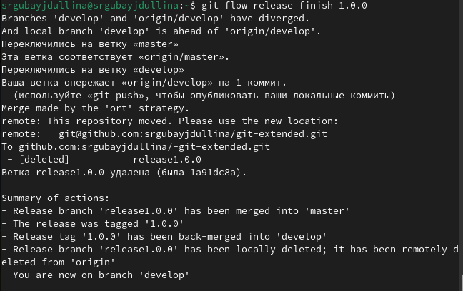

Перемещение релизной ветки в основную

## Практический сценарий использования git

Git push –all (рис. [-@fig:023]):

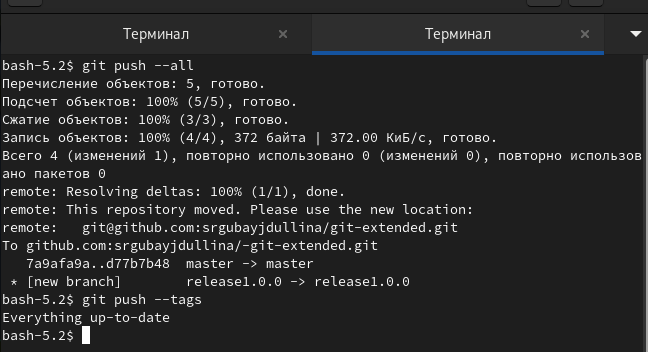

Отправка данных на GitHub

## Практический сценарий использования git

Создание релиза на github (рис. [-@fig:024]).

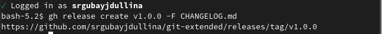

Релиз 1.0.0

## Работа с репозиторием git

6. Создаю ветку для новой функциональности (рис. [-@fig:025]).

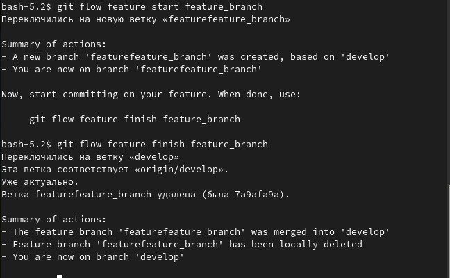

Создание ветки новой функциональности

## Работа с репозиторием git

Jбьединяю ветку feature_branch c develop и создаю релиз с версией 1.2.3 (рис. [-@fig:026]).

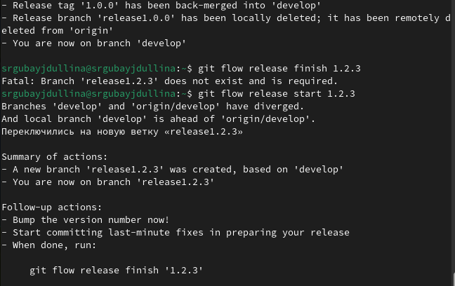

Создание релиза 1.2.3

## Работа с репозиторием git

Обновляю номер версии в файле package.json, установливаю её в 1.2.3 и создаю журнал изменений (рис. [-@fig:027]).

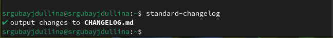

Создание журнала изменений

## Работа с репозиторием git

Добавляю журнал изменений в индекс (рис. [-@fig:028]).

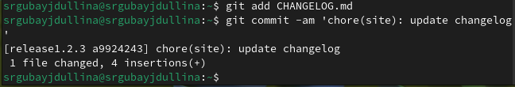

Добавление в индекс

## Работа с репозиторием git

Заливаю релизную ветку в основную ветку и отправляю данные на GitHub (рис. [-@fig:029]).

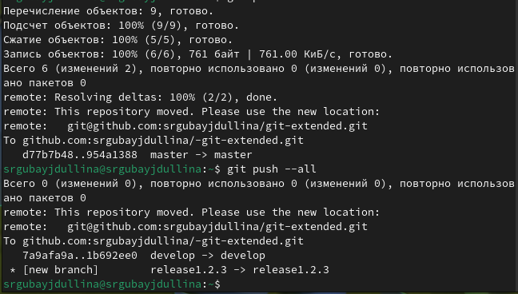

Перемещение ветки и отправка на сервер

## Работа с репозиторием git

Git push –tags (рис. [-@fig:030]):

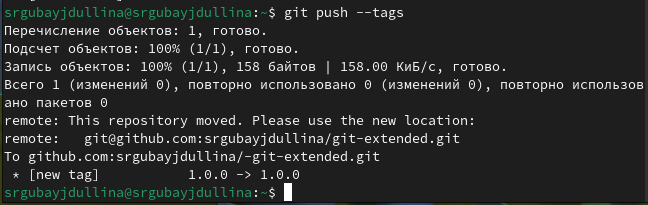

Отправка на сервер

## Работа с репозиторием git

Создаю релиз на github с комментарием из журнала изменений (рис. [-@fig:031]).

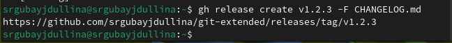

Создание релиза с комментарием

## Результаты

В ходе выполнения лабораторной работы я получила необходимые навыки правильной работы с репозиториями git. После проделанной работы мой репозиторий Git имеет продвинутую версию для использования.

## Итоговый слайд

Обычный Git хорошо, но продвинутый - лучше.